# Inference for Numerical Data, Part 2

## Your reproducible lab report

Before you get started, please download the R Markdown template for this lab. Remember all of your code and answers go in this document:

```r
download.file("https://jacobfhsmith.github.io/STA101-Fall-2021/sta101_lab7.Rmd", destfile="sta101_lab7.Rmd")
```

## North Carolina births

In 2004, the state of North Carolina released a large data set containing information on births recorded in this state. We used this data set last week and will use it again this week. This data set is useful to researchers studying health outcomes for babies. We will work with a random sample of observations from this data set.

## Packages

We will be using the `statsr` package that we used in Lab 5. We’ll also be using the `tidyverse` library (which includes `ggplot2` for visualization and `dplyr` for data manipulation).

```r
library(tidyverse)
library(statsr)
```

Remember, loading a package is something you need to do each time you launch a new R session and in each of your R Markdown files that have code that relies on this package.

## Exploratory analysis

Load the `ncbirths` data set into our work space.

```r
nc_births <- read_csv("~/ncbirths.csv")
```

We have observations on 13 different variables, some categorical and some numerical. The meaning of each variable is as follows.

### variable descriptions:

- `fage` father’s age in years.
- `mage` mother’s age in years.
- `mature` maturity status of mother.
- `weeks` length of pregnancy in weeks.
- `premie` whether the birth was classified as premature (premie) or full-term.
- `visits` number of hospital visits during pregnancy.
- `marital` whether mother is married or not married at birth.
- `gained` weight gained by mother during pregnancy in pounds.
- `weight` weight of the baby at birth in pounds.
- `lowbirthweight` whether baby was classified as low birthweight (low) or not (not low).
- `gender` assigned sex at birth, female or male.
- `habit` status of the mother as a nonsmoker or a smoker.
- `whitemom` whether mom is white or not white.

## Exercise 1 (20 points)

Make a side by side box plot for `premie` and the number of visits (`visits`) for **younger moms** only. What does the plot illustrate? Please describe the distribution for each category (both in terms of averages and outliers) and compare? (Filter out an NA values in `premie`, !is.na() may be useful.)

## Exercise 2 (15 points)

Use `summarize` in `dplyr` to obtain the mean number of office visits for **all** babies (i.e., those born to “younger moms” and those born to “mature moms.”) for each premie category. Do you think there is a significant difference between these two categories? What statistical method is suitable for quantify your guess? (Remember to filter out the NA values in `premie`)

## Exercise 3 (15 points)

We are interested in examining whether the mean number of office visits differs for premies and non-premies. What would be the null and alternative hypotheses here?

To carry out this hypothesis test, several conditions must be met, independence and normality, which can be found by checking sample size (and then looking for outliers). Using `dplyr` find the sample size for each group and discuss what this means for checking outliers. (We touched on independence with this data set on last week.)

## Inference example

The [`inference`](https://www.rdocumentation.org/packages/statsr/versions/0.1-0/topics/inference) function in R allows us to construct confidence intervals and carry out hypothesis tests.

Here is an example where we carry out a hypothesis test to find whether the mean weight of babies of non-smokers differs from that of the mean weight for smokers.

```r
inference(y = weight, x = habit, data = nc, statistic = "mean", type = "ht", null = 0, alternative = "twosided", method = "theoretical")
```

```
## Response variable: numerical
## Explanatory variable: categorical (2 levels)
## n_nonsmoker = 873, y_bar_nonsmoker = 7.1443, s_nonsmoker = 1.5187
## n_smoker = 126, y_bar_smoker = 6.8287, s_smoker = 1.3862
## H0: mu_nonsmoker =  mu_smoker
## HA: mu_nonsmoker != mu_smoker
## t = 2.359, df = 125
## p_value = 0.0199
```

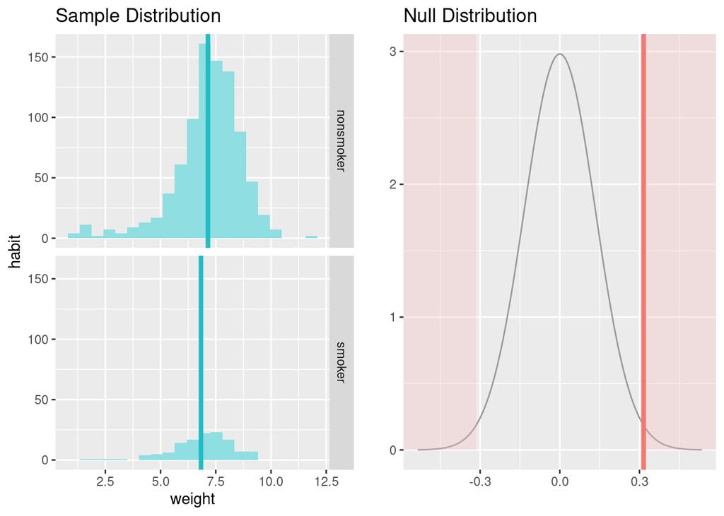

- 1st argument is y, which is the response variable that we are interested in: `weight`.
- 2nd argument is the explanatory variable, x, which is the variable that splits the data into two groups, smokers and non-smokers: `habit`.
- 3rd argument, “data”, is the data frame these variables are stored in.
- 4th is “statistic,” which is the sample statistic we’re using, or similarly, the population parameter we’re estimating. Recall in Lab 5 we worked with “proportion”.
- 5th we decide on the type of inference we want: a hypothesis test (“ht”) or a confidence interval (“ci”). When performing a hypothesis test, we also need to supply the null value, which in this case is 0, since the null hypothesis sets the two population means equal to each other. The alternative hypothesis can be “less”, “greater”, or “twosided”.
- Lastly, the method of inference can be “theoretical” or “simulation” based. “simulation” based means getting a sampling distribution of the target statistic by bootstrapping (taking many samples from the dataset). Here we are going to use “theoretical”.

## Exercise 4 (20 points)

Implement a difference of means test for the mean number of visits for premie babies compared to full term babies. Does the mean number of visits for babies in these two groups differ? Using the 0.05 significance level, interpret the results and state your conclusion.

## Exercise 5 (10 points)

Construct an equivalent confidence interval for the hypothesis above and discuss why you could make the same conclusion as in the previous question with only this information.

Now, we are going to examine how to carry out Chi-Square Tests in R. Chi-Square Tests can be used for a variety of purposes including testing for independence for categorical data that can be displayed in a table.

## Chi-Square test

There are a variety of ways to carry out a Chi-Square Test in R, but the `chisq.test()` command is especially useful. You can read more about that command [here](http://www.r-tutor.com/elementary-statistics/goodness-fit/chi-squared-test-independence).

## Exercise 6 (20 points)

Imagine that you want to test whether `mature` and `premie` are independent of one another. What would be your null and alternative hypotheses?

### References

Kelly Moran’s lab6: https://kelrenmor.github.io/STA101-002/labs/lab6/lab6

Modified from a lab originally made by Daniel Deng for Summer 2020.